# Eurovision Voting

Every May, millions of Europeans gather around their televisions to watch one of the worlds biggest spectacles and to partake in the cultural phenomenon that has shaped European relations since the fifites. The Eurovision Song Contest is held every year. Each of the 50 countries that participate send an artist or group to perform an original song. The result is a weeklong celebration of unity, peace, and cooperation. But also (maybe more importantly), a celebration of sequins, wind machines, and outrageous musical performances. You can read more about it [here](https://www.buzzfeed.com/ellievhall/everything-americans-need-to-know-about-eurovision) and [here](https://eurovision.tv/).

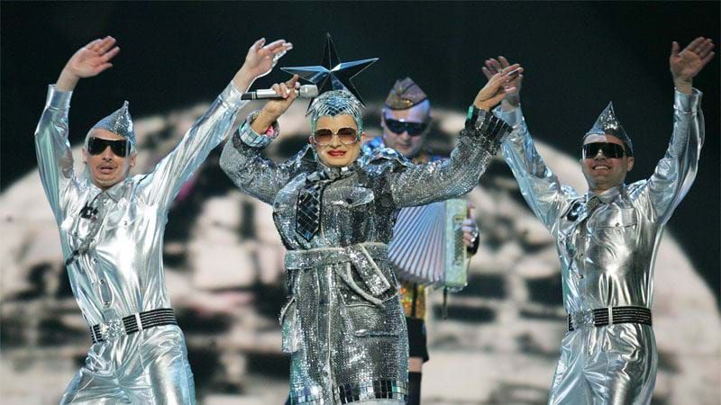

“hit.com.au”

To determine a winner, the viewers at home vote. The only rule is that you cannot vote for your own country. The votes are counted, and every country gives out 12, 10, 8 - 1 points to the 10 countries that received the most votes. These votes are then tallied and one country comes out victorious and will host the competition the following year.

The contest is non-political by nature, but neighbour voting, when people vote for the countries close to them, keeps coming up as an issue. Every year you hear complaints of neighbor-voting, or the opposite; complaints that a neighboring country *didn’t* give you enough points. Speaking from personal experience, I know that Norwegians are beyond annoyed if Sweden and Denmark do not give us enough points.

This neighbor voting is a problem that keeps surfacing in the competition, but is there actually a correlation between the distance between countries and the amount of votes they give each other?

In this tutorial we will examine the voting data from 1975 - 2019 to see if distance between countries make a significant difference in voting patterns.

(For the 2019 competition they changed the voting rules by adding a jury who has power over 50% of a country’s vote. You can read more about it [here](https://eurovision.tv/story/tonight-juries-decide-50-percent-of-the-eurovision-2019-result).)

## Data:

First we will import the voting data and examine the information it gives us. The dataset used here has been downloaded from kaggle. It can be found [here](https://www.kaggle.com/datagraver/eurovision-song-contest-scores-19752019/downloads/eurovision-song-contest-scores-19752019.zip/1) We will also be using a dataset with information about countries found [here](https://worldmap.harvard.edu/data/geonode:country_centroids_az8).

```r
eurovision <- read_excel("/Users/Astrid/Downloads/eurovision_song_contest_1975_2019.xlsx")
countries <- read_csv("/Users/Astrid/Downloads/country_centroids_az8.csv")

head(countries)
```

```
## # A tibble: 6 x 68
##   FID   the_geom  FID_ scalerank featurecla labelrank sovereignt sov_a3
##   <chr> <chr>    <dbl>     <dbl> <chr>          <dbl> <chr>      <chr>
## 1 coun… POINT (…     0         3 Admin-0 c…         5 Netherlan… NL1
## 2 coun… POINT (…     1         1 Admin-0 c…         3 Afghanist… AFG
## 3 coun… POINT (…     2         1 Admin-0 c…         3 Angola     AGO
## 4 coun… POINT (…     3         1 Admin-0 c…         6 United Ki… GB1
## 5 coun… POINT (…     4         1 Admin-0 c…         6 Albania    ALB
## 6 coun… POINT (…     5         3 Admin-0 c…         6 Finland    FI1
## # … with 60 more variables: adm0_dif <dbl>, level <dbl>, type <chr>,
## #   admin <chr>, adm0_a3 <chr>, geou_dif <dbl>, geounit <chr>,
## #   gu_a3 <chr>, su_dif <dbl>, subunit <chr>, su_a3 <chr>, brk_diff <dbl>,
## #   name <chr>, name_long <chr>, brk_a3 <chr>, brk_name <chr>,
## #   brk_group <chr>, abbrev <chr>, postal <chr>, formal_en <chr>,
## #   formal_fr <chr>, note_adm0 <chr>, note_brk <chr>, name_sort <chr>,
## #   name_alt <chr>, mapcolor7 <dbl>, mapcolor8 <dbl>, mapcolor9 <dbl>,
## #   mapcolor13 <dbl>, pop_est <dbl>, gdp_md_est <dbl>, pop_year <dbl>,
## #   lastcensus <dbl>, gdp_year <dbl>, economy <chr>, income_grp <chr>,
## #   wikipedia <dbl>, fips_10 <lgl>, iso_a2 <chr>, iso_a3 <chr>,
## #   iso_n3 <chr>, un_a3 <chr>, wb_a2 <chr>, wb_a3 <chr>, woe_id <dbl>,
## #   adm0_a3_is <chr>, adm0_a3_us <chr>, adm0_a3_un <dbl>,
## #   adm0_a3_wb <dbl>, continent <chr>, region_un <chr>, subregion <chr>,
## #   region_wb <chr>, name_len <dbl>, long_len <dbl>, abbrev_len <dbl>,
## #   tiny <dbl>, homepart <dbl>, Longitude <dbl>, Latitude <dbl>
```

```r
head(eurovision)
```

```
## # A tibble: 6 x 8
##    Year `(semi-) final` Edition `Jury or Televo… `From country`
##   <dbl> <chr>           <chr>   <chr>            <chr>
## 1  1975 f               1975f   J                Belgium
## 2  1975 f               1975f   J                Belgium
## 3  1975 f               1975f   J                Belgium
## 4  1975 f               1975f   J                Belgium
## 5  1975 f               1975f   J                Belgium
## 6  1975 f               1975f   J                Belgium
## # … with 3 more variables: `To country` <chr>, Points <dbl>,
## #   Duplicate <chr>
```

Here we see the 6 first rows in our datasets.

### Some observations we can make:

- The data shows us the point values given by each country to other contestants.
- Several column names have spaces in them, this will cause problems in r.
- The data does not tell us anything about the relationship between the countries, so we will have to add that.
- Some of the countries in ‘eurovision’ do no longer exist (e.g. Yugoslavia) or have changed names (e.g. Macedonia) and are therefore missing in ’countries.

## Tidying:

Now that we have our information in tables, we have to tidy the data to make it usable. We will do this in steps, fixing one problem at a time.

- Fix the column names that have spaces in them:
  - Write a function that replaces spaces with underscores, removes parentheses, and removes hyphens.

```r
names(eurovision)<-str_replace_all(names(eurovision), c(" " = "_", "\\(" = "", "\\)" = "", "-" = ""))
```

- Add information about the relationships between countries:
  - We will use data from our ‘countries’ table to calculate the distances between the countries.
  - First we have to import the longitude and latitude data from ‘countries’ to ‘eurovision’.
  - Then we make changes to ‘countries’ and ‘eurovision’ to prepare them for merging.

```r
#Select the attributes we need for 'eurovision'
countries <- countries %>%
  select(admin, continent, Longitude, Latitude)

#Filter out duplicates
eurovision <- eurovision %>% filter(is.na(Duplicate)) %>% select(-Duplicate)

#Change names in 'eurovision' in order to match 'countries' and vice versa.
eurovision$From_country[eurovision$From_country == "F.Y.R. Macedonia"] <- "Macedonia"
eurovision$To_country[eurovision$To_country == "F.Y.R. Macedonia"] <- "Macedonia"
eurovision$From_country[eurovision$From_country == "North Macedonia"] <- "Macedonia"
eurovision$To_country[eurovision$To_country == "North Macedonia"] <- "Macedonia"
eurovision$From_country[eurovision$From_country == "The Netherands"] <- "The Netherlands"
countries$admin[countries$admin == "Republic of Serbia"] <- "Serbia"
countries$admin[countries$admin == "Bosnia and Herzegovina"] <- "Bosnia & Herzegovina"
countries$admin[countries$admin == "Netherlands"] <- "The Netherlands"

#There are some countries that have competed in eurovision that do not exist anymore. Here, we add these countries to 'countries' and estimate the central coordinates based on its location in relation to modern countries.
countries <- rbind(countries, c("Yugoslavia", "Europe", 17.76876733, 44.17450125))
countries <- rbind(countries, c("Serbia & Montenegro", "Europe", 20.78958334, 44.2215032))

#Merge 'eurovision' and 'countries' by 'From_country' to add lat and lng
eurovision <- merge(x = eurovision, y = countries %>% select(Longitude, Latitude, admin), by.x = c("From_country"), by.y = c("admin"))
colnames(eurovision)[colnames(eurovision)=="Longitude"] <- "From_Longitude"
colnames(eurovision)[colnames(eurovision)=="Latitude"] <- "From_Latitude"

#Merge 'eurovision' and 'countries' by 'To_country' to add lat and lng
eurovision <- merge(x = eurovision, y = countries %>% select(Longitude, Latitude, admin), by.x = c("To_country"), by.y = c("admin"), all.x = TRUE)
colnames(eurovision)[colnames(eurovision)=="Longitude"] <- "To_Longitude"
colnames(eurovision)[colnames(eurovision)=="Latitude"] <- "To_Latitude"

#Make sure lng and lat data is numeric.
eurovision$From_Longitude <- as.numeric(eurovision$From_Longitude)
eurovision$From_Latitude <- as.numeric(eurovision$From_Latitude)
eurovision$To_Longitude <- as.numeric(eurovision$To_Longitude)
eurovision$To_Latitude <- as.numeric(eurovision$To_Latitude)

head(eurovision)
```

```
##   To_country From_country Year semi_final Edition Jury_or_Televoting
## 1    Albania        Malta 2011        sf1 2011sf1                  J
## 2    Albania      Belarus 2010          f   2010f                  J
## 3    Albania      Croatia 2008        sf2 2008sf2                  J
## 4    Albania       Israel 2019          f   2019f                  T
## 5    Albania  Switzerland 2005          f   2005f                  J
## 6    Albania    Australia 2017        sf1 2017sf1                  T
##   Points From_Longitude From_Latitude To_Longitude To_Latitude
## 1      0      14.405233      35.92150     20.04983    41.14245
## 2      0      28.032093      53.53131     20.04983    41.14245
## 3     10      16.404129      45.08048     20.04983    41.14245
## 4      0      35.004447      31.46110     20.04983    41.14245
## 5     10       8.208675      46.79786     20.04983    41.14245
## 6      0     134.491000     -25.73289     20.04983    41.14245
```

- Now that we have longitude and latitude information for both to- and from-countries, we can create a column that measures the distance between the center of the countries. Here we will use the funtion ‘distHaversine’ in order to measure the distance between two coordinates, taking into account the curvature of the earth and other important factors. There is more information on this [here](https://www.geeksforgeeks.org/haversine-formula-to-find-distance-between-two-points-on-a-sphere/).

```r
library(data.table)
library(geosphere)


setDT(eurovision)
eurovision <- eurovision[, distance_hav := distHaversine(matrix(c(From_Longitude, From_Latitude), ncol = 2),
                                   matrix(c(To_Longitude, To_Latitude), ncol = 2))]
```

## Exploratory Data Analysis:

Now that we have cleaned up the data and added some information to the table, we can start taking an initial look at our data.

Because we are looking for correlation between voting and distance between countries, we will make some initial discoveries about the data.

First we can look at the countries who have received the most points in the competition:

```r
eurovision %>%
  group_by(To_country) %>%
  summarise(Point_sum = sum(Points)) %>%
  arrange(desc(Point_sum)) %>%
  head()
```

```
## # A tibble: 6 x 2
##   To_country      Point_sum
##   <chr>               <dbl>
## 1 Sweden               6818
## 2 Russia               4975
## 3 Norway               4812
## 4 Greece               4466
## 5 Israel               4376
## 6 The Netherlands      4175
```

We can find an ordering of the total sum of points given from one country to another.

```r
  eurovision %>%
  group_by(From_country, To_country) %>%
  summarize(total_point = sum(Points)) %>%
  arrange(desc(total_point))  %>%
  head()
```

```
## # A tibble: 6 x 3
## # Groups:   From_country [5]
##   From_country   To_country total_point
##   <chr>          <chr>            <dbl>
## 1 Cyprus         Greece             467
## 2 Greece         Cyprus             448
## 3 Denmark        Sweden             437
## 4 Norway         Sweden             416
## 5 United Kingdom Ireland            302
## 6 Norway         Denmark            291
```

This data gives us more confidence as we keep exploring our data. All the top voting exchanges have been between countries in the same regioins of Europe.

One more check we can do is by building a network graph. This will show us the relationships between the countries’ voting records, and by sizing the edges according to the amount of votes given, we will be able to see more about the countries who have a history of voting for each other.

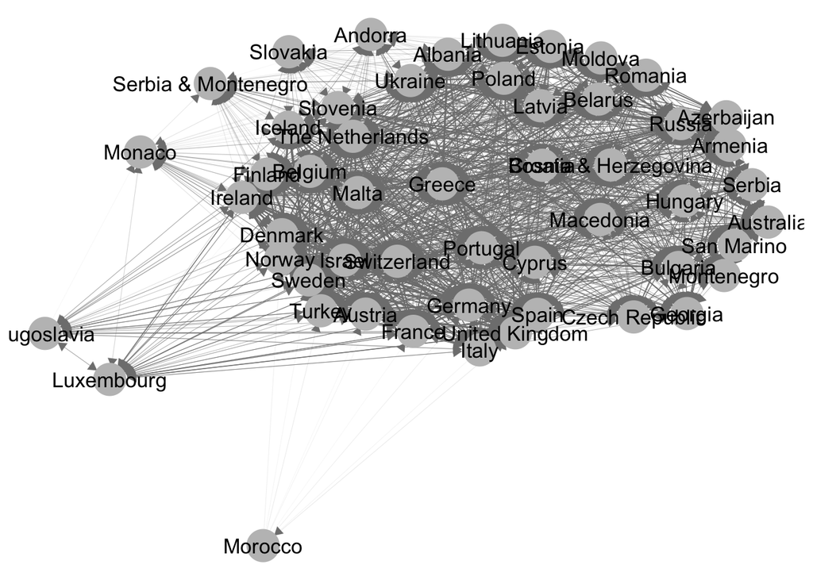

```r
library(GGally)
library(network)
library(sna)
library(ggplot2)


eurovision_temp <- eurovision %>% group_by(From_country, To_country) %>% summarize(total_point = sum(Points))

#Remove edges where the weight is zero
eurovision_temp <- eurovision_temp[!(eurovision_temp$To_country==eurovision_temp$From_country | eurovision_temp$total_point == 0),]

#Make sure every edge weight is between in (0,1)
eurovision_temp$edge_weight <- eurovision_temp$total_point / 470

#Round up all edges with a weight lower than 0.01 to 0.01 in order to see them more clearly.
eurovision_temp$edge_weight[eurovision_temp$edge_weight < 0.01] <- 0.01

my_net = network(eurovision_temp %>% select(From_country, To_country), directed = TRUE, matrix.type="edgelist")

ggnet2(my_net, label = TRUE, arrow.size = 6, arrow.gap = 0.025, edge.size = as.vector(eurovision_temp$edge_weight))
```

This graph is a little too messy for our purposes. There are too many arrows pointing to every vertex, making it hard to distinguish details.

Because we mostly care about the higher number of votes in our EDA section, we can extract the relationships between countries that have the most votes between them. Let’s try plotting the countries above that lie above 50% of the top sum:

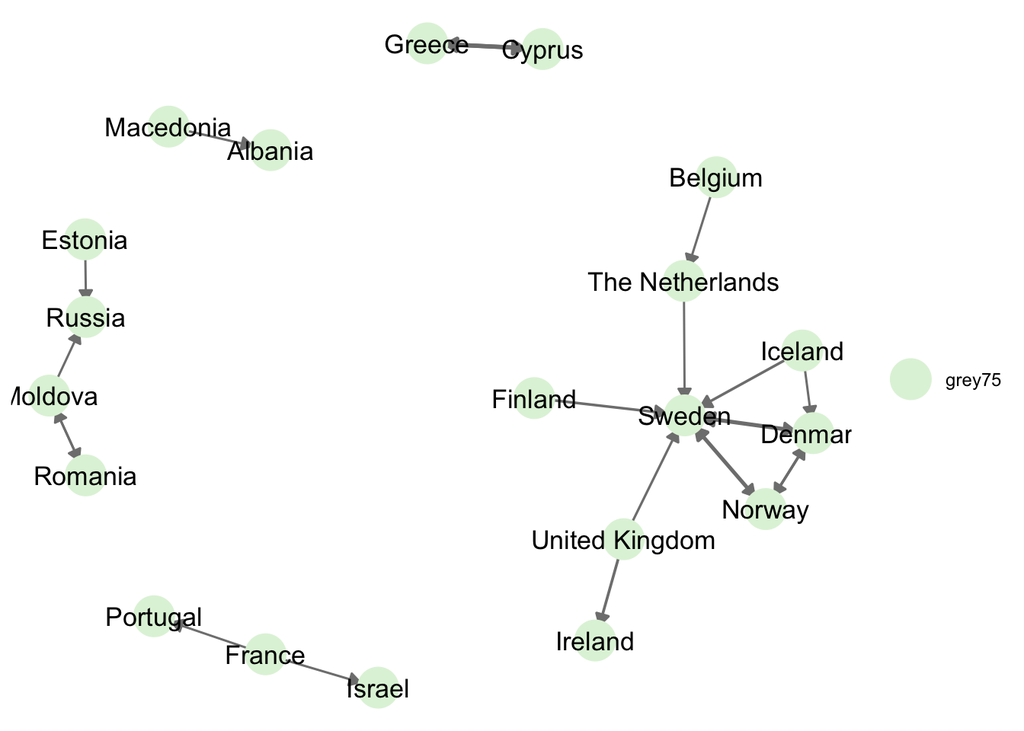

```r
library(RColorBrewer)
eurovision_temp1 <- eurovision_temp %>% filter(edge_weight >= 0.5)

my_net = network(eurovision_temp1 %>% select(From_country, To_country), directed = TRUE, matrix.type="edgelist")

ggnet2(my_net, label = TRUE, directed = TRUE, arrow.size = 6, arrow.gap = 0.025, edge.size = as.vector(eurovision_temp1$edge_weight), palette = "GnBu")
```

This is again very interesting, and the information is still in line with our hypothesis that proximity plays an important role in voting. The groups of vertices we see here are all somewhat connected to the countries in their respective groups. One group has many of the northern european countries plus the UK, Ireland, The Netherlands, and Belgium. Another group has Greece and Cyprus, another has Albania and Macedonia. As we predicted earlier, these groups of countries are connected both culturally and geographically and it gives us a good start for our more in-depth statistical experiment.

## Clustering and Regression Analysis:

So far, we have used a lot of approximation in our exploration of the data. Our hypothesis that neighbour voting plays a significant role has not been disproven yet, so now we can dig deeper with some statistical analysis.

First we have to determine how many clusters are optimal for our data:  
- To achieve more precise results, we’ll standardize and center our data.  
- Because of the unproportional distances, we will filter out Australia from our tables to minimize the outliers.

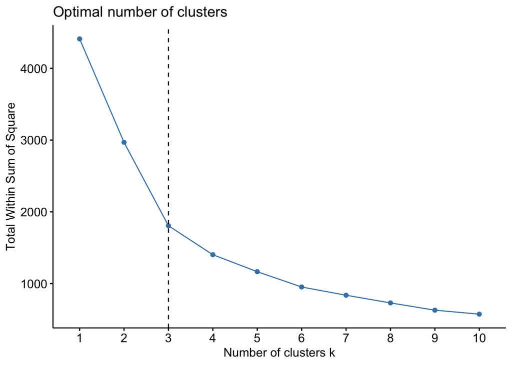

```r
library(factoextra)

eurovision_temp <-
  merge(x = eurovision_temp, y = eurovision %>% select(distance_hav, To_country, From_country), by = c("To_country", "From_country"), all.x = TRUE) %>%
  distinct()

eurovision_temp <- eurovision_temp %>%
  filter(From_country != "Australia") %>%
  filter(To_country != "Australia")

#Standardizing distance and point values
standardized_euro <- eurovision_temp %>%
  mutate(mean_point = mean(total_point)) %>%
  mutate(sd_point = sd(total_point)) %>%
  mutate(z_point = (total_point - mean_point) / sd_point) %>%
  mutate(mean_dist = mean(distance_hav)) %>%
  mutate(sd_dist = sd(distance_hav)) %>%
  mutate(z_dist = (distance_hav - mean_dist) / sd_dist)

set.seed(20)

fviz_nbclust(standardized_euro[,8:11], kmeans, method = "wss") + geom_vline(xintercept = 3, linetype = 2)
```

- Because this the “elbow method” of deriving the optimal number of clusters, we are looking for the value in the bend of the graph, here that is 3.
- Now that we know the optimal number of clusters, we can perform a cluster analysis on our data with 3 clusters.

```r
clusters <- kmeans(standardized_euro[,8:11], 3)

#Add the cluster number to each entity
standardized_euro$Cluster_num <- as.character(clusters$cluster)

str(clusters)
```

```
## List of 9
##  $ cluster     : int [1:2206] 3 3 3 2 3 3 3 3 1 3 ...
##  $ centers     : num [1:3, 1:4] 1.79 -7.86e-02 -4.30e-01 1.85e+06 1.85e+06 ...
##   ..- attr(*, "dimnames")=List of 2
##   .. ..$ : chr [1:3] "1" "2" "3"
##   .. ..$ : chr [1:4] "z_point" "mean_dist" "sd_dist" "z_dist"
##  $ totss       : num 4410
##  $ withinss    : num [1:3] 539 647 620
##  $ tot.withinss: num 1807
##  $ betweenss   : num 2603
##  $ size        : int [1:3] 341 547 1318
##  $ iter        : int 3
##  $ ifault      : int 0
##  - attr(*, "class")= chr "kmeans"
```

- An interesting value to note here is the sizes, one cluster is much larger than the other two.
- Now we can create visual output to see if our hypothesis is correct or not.
  - First we’ll plot all the data entries in a scatterplot to look for general trends:

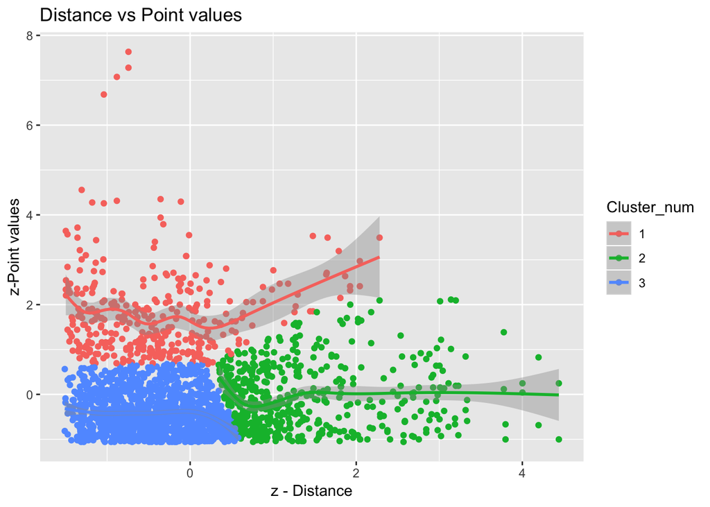

```r
standardized_euro %>%
  ggplot(aes(x=z_dist, y=z_point, color=Cluster_num)) +
  geom_point() +
  geom_smooth() +
  labs(title = "Distance vs Point values", x= "z - Distance", y="z-Point values")
```

This information does not look good for our hypothesis. It looks like distance does not have a large effect on how many points countries give to each other, most of the points are even centered where the distance and point scores both are low. The fairly horizontal regrssion lines show us that the average distance between points remains fairly similar despite the distance.

- To learn more about the data, we’ll narrow down our scope:
  - We’ll extract the relationships with the maximum number of votes per to-country. This will give us information about the most frequently used voting channels.

```r
#Extract the maximum scores for each country
network_euro <- standardized_euro %>%
  group_by(To_country) %>%
  summarize(max_point <- max(total_point))

#Merge the maximim scores into the table
standardized_euro <- merge(x=standardized_euro, y=network_euro, by=c("To_country"))

#Filter out the relationships that have the most points
network_euro <- standardized_euro %>% filter(total_point == `max_point <- max(total_point)`)
```

- Now that we have narrowed down our search, we can plot more graphs to learn more about the data:

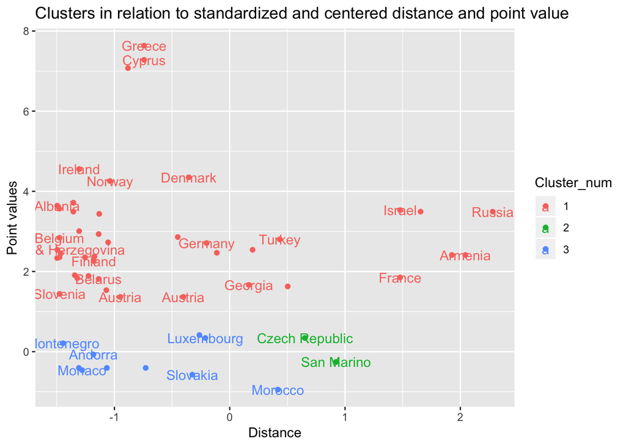

```r
network_euro %>%
ggplot(aes(x=z_dist, y = z_point, color = Cluster_num, label = To_country)) +
  geom_point() +
    labs(title = "Clusters in relation to standardized and centered distance and point value", x = "Distance", y = "Point values") +
  geom_text(check_overlap = TRUE)
```

This scatter plot is interesting to us, because the majority of the countries lie on the lower half of the distance scale. Because this is information about the countries with the highest point relationships, this tells us that These high-point relationships tend to be among closer countries.

Before we round off, we’ll come back to the network graph we plotted before, now with colors for each of the clusters:

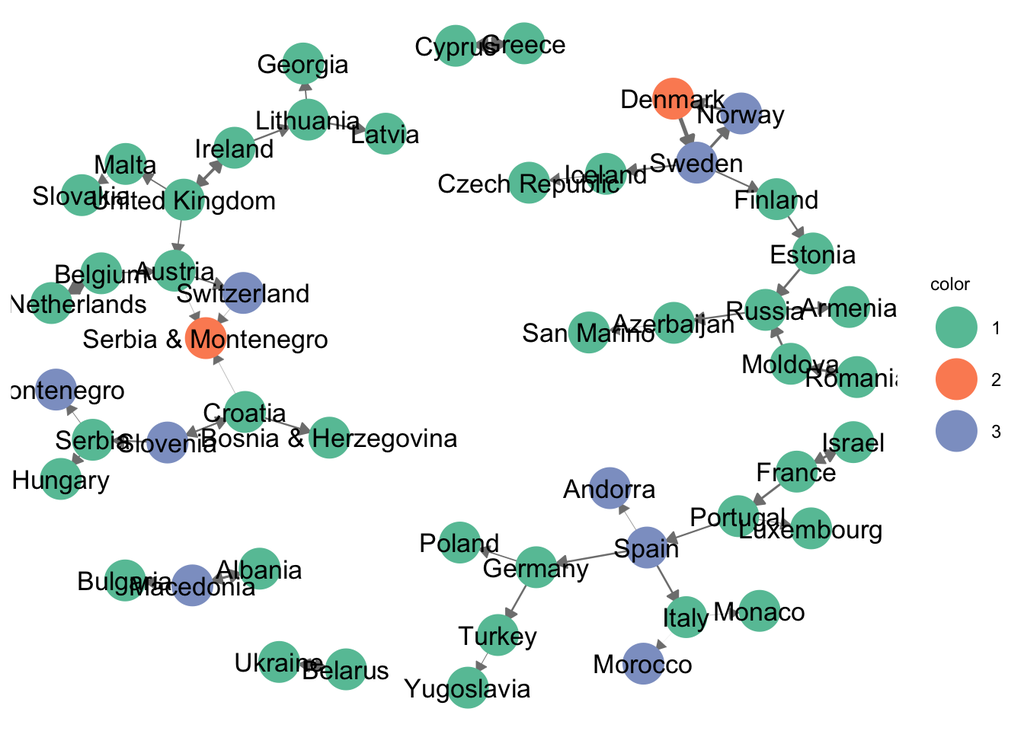

```r
my_net <- network(network_euro %>% select(From_country, To_country), directed = TRUE, matrix.type="edgelist")
my_net %v% "color" = ifelse(network_euro$Cluster_num %in% c("1"), "1", (ifelse(network_euro$Cluster_num %in% c("2"), "2", "3")))

ggnet2(my_net, label = TRUE, arrow.size = 6, arrow.gap = 0.025, edge.size = as.vector(network_euro$edge_weight), color = "color", palette = "Set2")
```

As before, this graph is a little too crowded for us to gain a lot of insight. If we narrow the data down to countries with a point value above three we see more patterns.

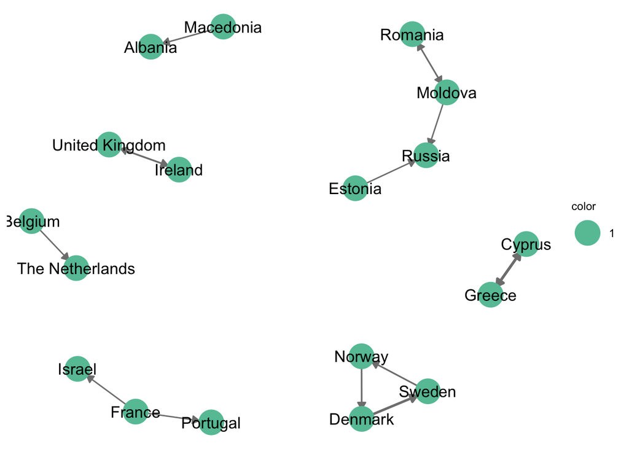

```r
network_euro1 <- network_euro %>% filter(z_point > 3) %>% filter(Cluster_num == 1)

my_net <- network(network_euro1 %>% select(From_country, To_country), directed = TRUE, matrix.type="edgelist")
my_net %v% "color" = ifelse(network_euro1$Cluster_num %in% c("1"), "1", (ifelse(network_euro1$Cluster_num %in% c("2"), "2", "3")))

ggnet2(my_net, label = TRUE, arrow.size = 6, arrow.gap = 0.025, edge.size = as.vector(network_euro1$edge_weight), color = "color", palette = "Set2")
```

This graph shows us that there are some strong connections between the countries that give each other the most points. If we look back to the table we found early on in the process with the countries who have received the most votes, some of which include Sweden, Russia, Norway, and Greece, we see that these countries all show up on this network graphs. This tells us that the clusters are powerful in predicting what countries will receive many points, at least in the long run.

## Conclusion:

While our hypothesis seemed promising for most of the experiment, the regression analysis showed us that there isn’t a clear relationship between distance and amount of points.

But our troubles weren’t for nothing: We saw that the countries with the most points over the time interval 1975-2019 all have strong connections with neighboring countries. These relationships might not lead the country to victory each year, but a strong alliance with other countries will at least give you a chance to go for gold.

Maybe the secret to doing well in Eurovision is simply to add more glitter? That sounds like a good topic for further investigation.